# Project 2

Your Name

2023-02-05

## Overview

This document provides high-level information on whether the minimum legal drinking age (MLDA) makes any difference in the likelihood of consuming alcohol. It includes:

- Code to read in and clean data
- Summary Statistics
- Regression output

## Data and Summary Statistics

The data come from a nationally representative survey, and the data come in the structure below:

```
## # A tibble: 61,263 × 11
##    hs_diploma hispanic white black emplo…¹ married  male days_21 perc_…² drink…³
##         <dbl>    <dbl> <dbl> <dbl>   <dbl>   <dbl> <dbl>   <dbl>   <dbl>   <dbl>
##  1          0        1     0     0       1       1     1    1601   0.548       0
##  2          1        1     0     0       1       0     0    1024   1.10        1
##  3          1        0     0     1       1       0     0    2455   6.58        1
##  4          0        1     0     0       1       0     1    -590   0           0
##  5          0        1     0     0       0       1     0    1815   0           0
##  6          1        0     0     1       1       1     0    2424   0           0
##  7          1        0     0     1       1       0     0    1116   3.29        1
##  8          1        0     0     1       1       0     0    2942   0.548       0
##  9          1        1     0     0       1       0     0    2516   3.29        1
## 10          1        0     0     1       1       0     0    2516  57.0         1
## # … with 61,253 more rows, 1 more variable: student <dbl>, and abbreviated
## #   variable names ¹employed, ²perc_days_drink, ³drinks_alcohol
```

## Some quick data exploration

- The share who drink alcohol is 0.62 and the share who are students is 0.1.

## Transform and explore

Below is some code to generate summary statistics.

```r
# add a new variable for age in years and a heavy drinker variable if they drink more than 75% of days
mlda <- mutate(mlda,
               age_years = 21 + days_21/365,
               heavy_drinker = if_else(perc_days_drink > 75, 1, 0))

# filter to just underage drinkers
underage <- filter(mlda, days_21 < 0 & drinks_alcohol == 1)

# demographic characteristics of underage drinkers
summ_stats_underage <- summarise(underage,
          min_age = min(age_years),
          mean_age = mean(age_years),
          median_age = median(age_years),
          mean_heavy_drinker = mean(heavy_drinker),
          mean_white = mean(white),
          mean_black = mean(black),
          mean_hispanic = mean(hispanic))

summ_stats_underage
```

```
## # A tibble: 1 × 7
##   min_age mean_age median_age mean_heavy_drinker mean_white mean_black mean_hi…¹
##     <dbl>    <dbl>      <dbl>              <dbl>      <dbl>      <dbl>     <dbl>
## 1    17.7     19.7       19.8             0.0166      0.661     0.0947     0.203
## # … with abbreviated variable name ¹mean_hispanic
```

## The Pipe

- The pipe operate `%>%` takes output from on function and ‘pipes’ it into another function

```r
x <- paste("A", "String")
print(x)

print(paste("A", "String"))

paste("A", "String") %>%
  print(.)
```

## Use the pipe operator to combine all of these into one ‘dplyr chain’

- The period denotes where the previous output should be the argument in the new function

```r
summ_stats <- mutate(mlda,
                     age_years = 21 + days_21/365,
                     heavy_drinker = if_else(perc_days_drink > 75, 1, 0)) %>%
  filter(., days_21 < 0 & drinks_alcohol == 1) %>%
  summarise(.,min_age = min(age_years),
          mean_age = mean(age_years),
          median_age = median(age_years),
          mean_perc_days_drink = mean(perc_days_drink),
          median_perc_days_drink = median(perc_days_drink))

summ_stats
```

```
## # A tibble: 1 × 5
##   min_age mean_age median_age mean_perc_days_drink median_perc_days_drink
##     <dbl>    <dbl>      <dbl>                <dbl>                  <dbl>
## 1    17.7     19.7       19.8                 13.3                   6.58
```

## More Summary Statistics

Summary statistics for heavy drinkers vs non-heavy drinkers.

```
## # A tibble: 2 × 6
##   heavy_drinker min_age mean_age median_age mean_student     n
##           <dbl>   <dbl>    <dbl>      <dbl>        <dbl> <int>
## 1             0    17.8     24.7       24.9       0.0874 37322
## 2             1    17.7     25.3       25.7       0.0425   964
```

## Try yourself

```
## # A tibble: 2 × 5
##   student_drinker mean_male mean_white mean_black mean_hispanic
##             <dbl>     <dbl>      <dbl>      <dbl>         <dbl>
## 1               0     0.439      0.543     0.155          0.250
## 2               1     0.545      0.686     0.0966         0.120
```

## Export as a table

- use kable to export as a table
- can make aesthetic changes to the table, add labels, etc.

Drinking Patterns among Underage Drinkers

| Min Age | Mean Age | Med Age | Heavy Drinker | White | Black | Hispanic |
| --- | --- | --- | --- | --- | --- | --- |
| 17.7 | 19.67 | 19.75 | 0.02 | 0.66 | 0.09 | 0.2 |

## Visual: age distribution of drinkers vs non-drinkers?

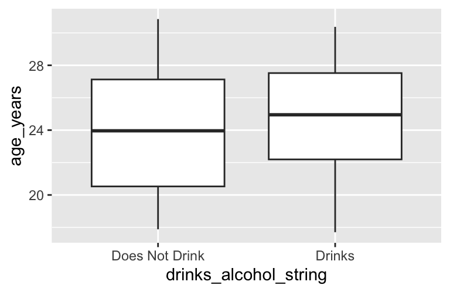

## Run a Model

- Use a linear probability model to predict the effect of age in years on the likelihood of drinking alcohol
- we can use lm()

## Model our data

```r
# lpm of years in age on likelihood of drinking alcohol
lpm1 <- lm(formula = drinks_alcohol ~ age_years, data = mlda )
```

```r
summary(lpm1)
```

[output not shown]

## Exercise

- Now, add an age squared and age cubed variable to your dataset and rerun the model
- inspect your results

## Use Stargazer to output your results

|  | *Dependent variable:* |  |
| --- | --- | --- |
|  | Probabilty of Drinking |  |
|  | (1) | (2) |
| age_years | 0.017*** | 1.697*** |
|  | (0.001) | (0.104) |
| age_sq |  | -0.065*** |
|  |  | (0.004) |
| age_cu |  | 0.001*** |
|  |  | (0.0001) |
| Constant | 0.200*** | -13.996*** |
|  | (0.014) | (0.817) |
| Observations | 61,263 | 61,263 |
| R<sup>2</sup> | 0.015 | 0.031 |
| Adjusted R<sup>2</sup> | 0.015 | 0.031 |
| Residual Std. Error | 0.481 (df = 61261) | 0.476 (df = 61259) |
| F Statistic | 927.281*** (df = 1; 61261) | 661.294*** (df = 3; 61259) |
| *Note:* | p<0.1; p<0.05; p<0.01 |  |

## Output model results

|  | *Dependent variable:* |  |  |
| --- | --- | --- | --- |
|  | Probabilty of Drinking with Controls |  |  |
|  | (1) | (2) | (3) |
| age_years | 0.017*** | 1.697*** | 1.710*** |
|  | (0.001) | (0.104) | (0.102) |
| age_sq |  | -0.065*** | -0.066*** |
|  |  | (0.004) | (0.004) |
| age_cu |  | 0.001*** | 0.001*** |
|  |  | (0.0001) | (0.0001) |
| student |  |  | -0.025*** |
|  |  |  | (0.007) |
| male |  |  | 0.179*** |
|  |  |  | (0.004) |
| Constant | 0.200*** | -13.996*** | -14.167*** |
|  | (0.014) | (0.817) | (0.803) |
| Observations | 61,263 | 61,263 | 61,263 |
| R<sup>2</sup> | 0.015 | 0.031 | 0.065 |
| Adjusted R<sup>2</sup> | 0.015 | 0.031 | 0.065 |
| Residual Std. Error | 0.481 (df = 61261) | 0.476 (df = 61259) | 0.468 (df = 61257) |
| F Statistic | 927.281*** (df = 1; 61261) | 661.294*** (df = 3; 61259) | 855.417*** (df = 5; 61257) |
| *Note:* | p<0.1; p<0.05; p<0.01 |  |  |

## Visualize the discontinuity

```
## [1] "Mass points detected in the running variable."
```

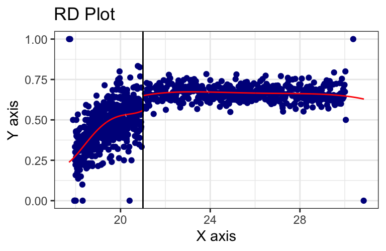

## Conclusion and Takeaways

- It seems that the minimum legal drinking age has some effect